# PGY1 Residency Interviews Feedback Survey

Brian Gulbis  
April 19, 2016

### Survey Overview

- Survey was sent to all 35 candidates who interviewed
- There were 29 candidates who completed the survey
  - Response rate of 82.9%

### Questions Asked

- When researching residency programs, how did you first learn about the PGY1 residency program at Memorial Hermann-Texas Medical Center?
- What factors were most important to you when deciding what order to rank residency programs?
- How would you rate each of these components of your interview day?
  - Residency Program Director interactions
  - Preceptor interactions
  - Resident interactions
  - Multiple Mini Interviews
  - Lunch
  - Tour

### Questions Asked

- Did the use of the Multiple Mini Interview format influence the way you ranked our residency program?
- Where did you rank Memorial Hermann-Texas Medical Center?
- If Memorial Hermann-Texas Medical Center was not your first choice, what was the primary reason (or reasons) why?
- Please provide any suggestions you have to improve the interview process at Memorial Hermann-Texas Medical Center for next year's residency candidates.

### Question 1

How candidates first heard about our program

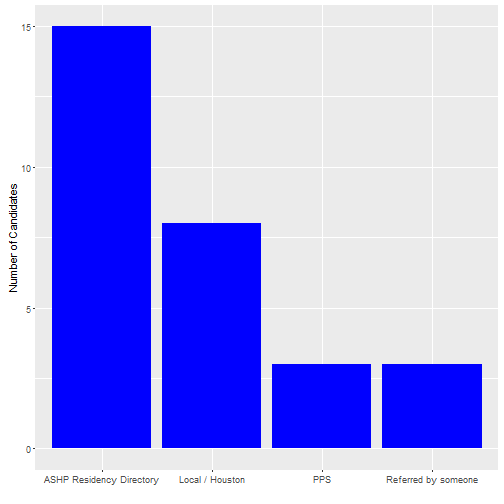

### Question 2

Factors that influenced ranking decisions

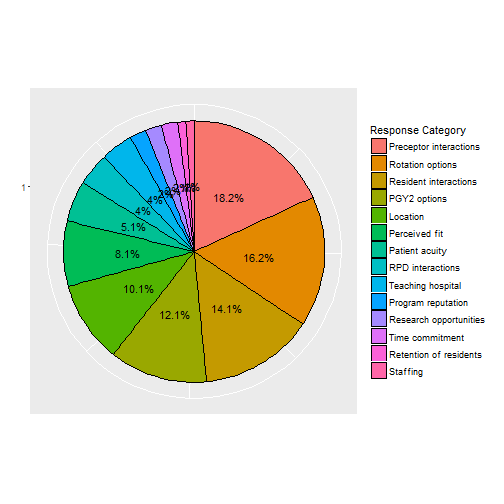

### Question 3

Ratings of each component of the interview day

|  | Lunch | MMI | Preceptor | Resident | RPD | Tour |
| --- | --- | --- | --- | --- | --- | --- |
| n | 29 | 29 | 29 | 29 | 29 | 29 |
| Score (%) |  |  |  |  |  |  |
| Poor | 0 | 0 | 0 | 3 | 0 | 3 |
| Below Average | 0 | 3 | 0 | 10 | 7 | 3 |
| Average | 52 | 28 | 24 | 14 | 34 | 21 |
| Above Average | 28 | 52 | 38 | 38 | 14 | 24 |
| Excellent | 21 | 17 | 38 | 34 | 45 | 48 |

### Question 4

MMI influence on program ranking

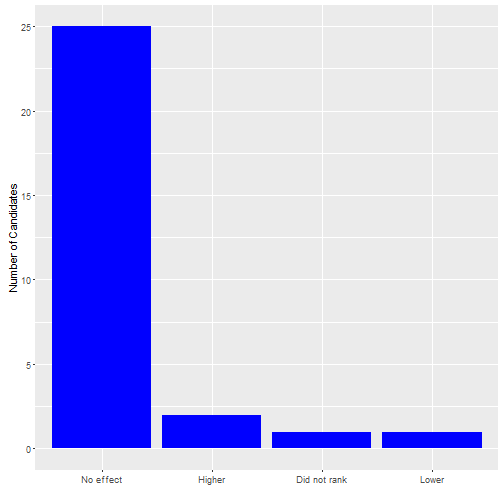

### Question 5

Where our program was ranked

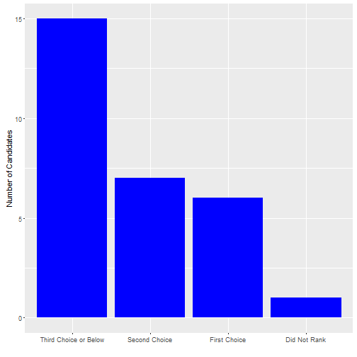

### Question 6

Factors that caused us to be ranked lower than first

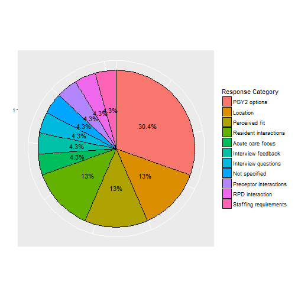

### Question 7

Suggestions to improve the interview day

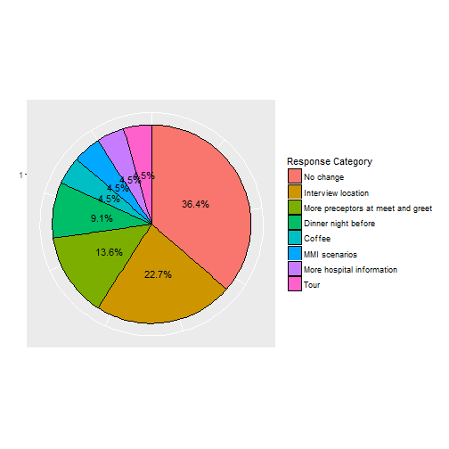